# st231 assignment

Jingyu Zhang

2026-04-06

```
Call:
lm(formula = log(price) ~ log(x), data = diamonds)

Residuals:
     Min       1Q   Median       3Q      Max
-0.53162 -0.11695 -0.01271  0.12846  0.37192

Coefficients:
            Estimate Std. Error t value Pr(>|t|)
(Intercept) -2.46260    0.10353  -23.79   <2e-16 ***
log(x)       5.92967    0.05687  104.27   <2e-16 ***
---
Signif. codes:  0 '***' 0.001 '**' 0.01 '*' 0.05 '.' 0.1 ' ' 1

Residual standard error: 0.168 on 605 degrees of freedom
Multiple R-squared:  0.9473,    Adjusted R-squared:  0.9472
F-statistic: 1.087e+04 on 1 and 605 DF,  p-value: < 2.2e-16
```

a.From summary, $M1: \log(\text{price}) = 5.92967 \cdot \log(x) - 2.46260$

From Jeweller, $price \propto weight^{log1.21/log1.10}$,then $price \propto weight^{2}$

By geometrical background and constant density $ weightx^3$

Then, combine both the information from Jeweller and geometrical background, $price \propto x^{6}$, taking log, we get $log(price) \propto 6logx$

This theoretical coefficient of 6 is very close to the estimated coefficient 5.92967 from model M1, suggesting that the fitted model is reasonable.

b.From Jeweller, $price \propto weight^{2}$

By geometrical background and constant density $weight \propto x \cdot y \cdot z$

Combine these two and taking log, we get $log(price)\propto 2log(x)+2log(y)+2log(z)$

Then, approximate values for $\beta_1$, $\beta_2$ and $\beta_3$ are both 2.

```
Call:
lm(formula = log(price) ~ log(x) + log(y) + log(z), data = diamonds)

Residuals:
    Min      1Q  Median      3Q     Max
-0.4187 -0.1173 -0.0137  0.1282  0.3530

Coefficients:
            Estimate Std. Error t value Pr(>|t|)
(Intercept)  -1.7674     0.1524 -11.595  < 2e-16 ***
log(x)       -0.1621     0.8102  -0.200    0.842
log(y)        4.3858     0.7800   5.623 2.87e-08 ***
log(z)        1.7823     0.2544   7.006 6.59e-12 ***
---
Signif. codes:  0 '***' 0.001 '**' 0.01 '*' 0.05 '.' 0.1 ' ' 1

Residual standard error: 0.1579 on 603 degrees of freedom
Multiple R-squared:  0.9535,    Adjusted R-squared:  0.9533
F-statistic:  4126 on 3 and 603 DF,  p-value: < 2.2e-16
```

$\mathbb{E}[log(Price_j)]$ = $\beta_0+\beta_1log(xj)+\beta_2log(y_j)+\beta_3log(z_j)$

To test $H_0$:$\beta_1=0$ vs $H_1$:$\beta_1 \not= 0$ we use a t-test. The number of units of observation in the dataset is $n=607$ and the M2 model has $p=4$ parameters. Hence, under $H_0$, the $T$-statistic, defined as $\frac{\widehat{\beta_1}}{{\rm std.error}(\widehat{\beta_1})}$ has a $t$-distribution on $n-p=607-4 = 603$ degrees of freedom. As is listed in the 2nd row of the table of coefficients, the observed value of the $T$-statistic is $T_{\rm obs} = -0.200$ which has a $p$-value of $0.842$. Thus there is insufficient evidence at the 5% level to reject the null hypothesis that $\beta_1=0$. We conclude that including log(x) does not have significant improvement after accounting for log(y) and log(z) in the model. Hence we do not include log(x) term in the model.

|  | Df | Sum Sq | Mean Sq | F value | Pr(>F) |
| --- | --- | --- | --- | --- | --- |
| log(x) | 1 | 306.7623691 | 306.76236909 | 12296.29214 | 0.000000e+00 |
| log(y) | 1 | 0.8035261 | 0.80352614 | 32.20862 | 2.152387e-08 |
| log(z) | 1 | 1.2244478 | 1.22444777 | 49.08088 | 6.586593e-12 |
| Residuals | 603 | 15.0433730 | 0.02494755 | NA | NA |

This result is not contradictory to part (c). The test in (c) examines whether log(x) is significant after accounting for log(y) and log(z), while sequential ANOVA tests whether log(x) is significant alone. The high correlation between x, y, and z explains why log(x) appears insignificant in part (c) but highly significant in sequential ANOVA.

In the context of round diamonds, the physical dimensions x, y and z (length, width, depth) are inherently highly correlated, as they all describe the overall size of the stone. A diamond that is large in one dimension will almost certainly be large in the others. This strong linear dependence means the three log-transformed variables carry largely overlapping information.

Numerically, this can be supported by high pairwise correlation coefficients between log(x), log(y) and log(z). Graphically, the scatterplot matrix of these variables would show strong linear associations, visually confirming the severe multicollinearity that distorts the individual slope estimates in M2.

```
      x     y     z
x 1.000 0.998 0.978
y 0.998 1.000 0.976
z 0.978 0.976 1.000
```

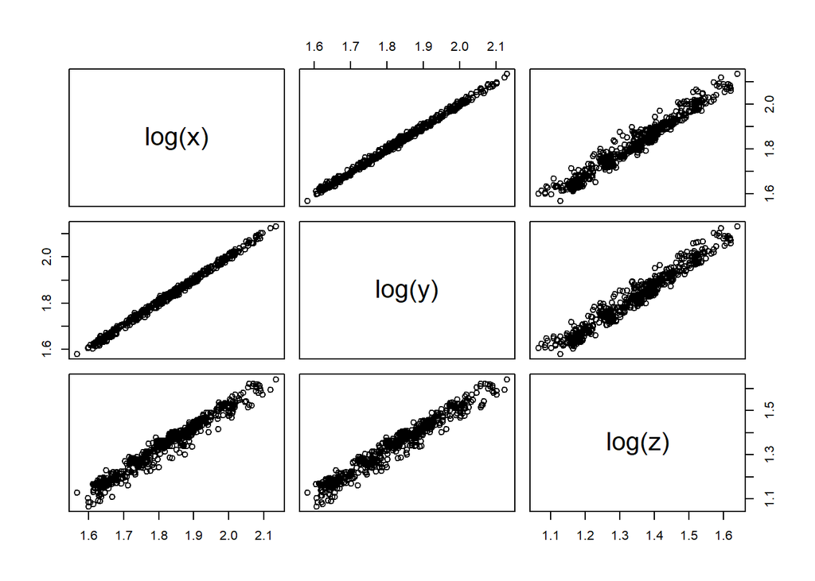

A scatterplot matrix of the three explanatory variables log(x), log(y) and log(z) from diamonds dataset. We see that each pair of log(x), log(y) and log(z) all have a strong linear relationship

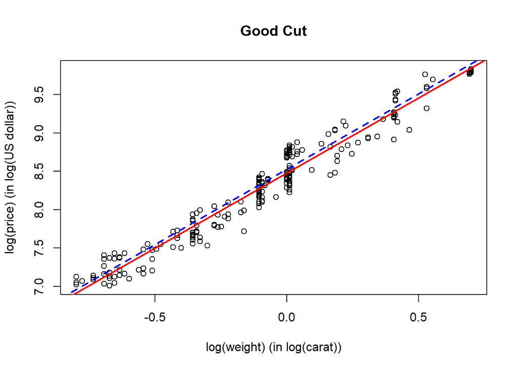

Three scatterplots for log(weight) against log(price) categorised by Cut. The red line is the fitted regression line for diamonds subset categorised by Cut, and the blue line is the fitted line from model M3 using the full dataset.

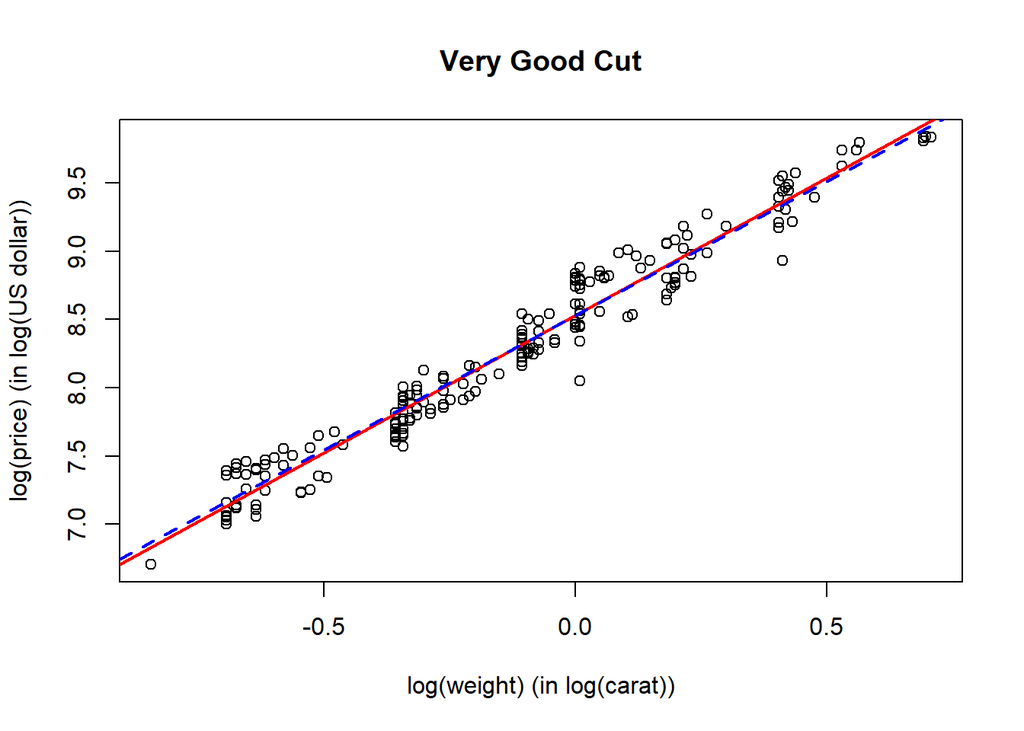

Three scatterplots for log(weight) against log(price) categorised by Cut. The red line is the fitted regression line for diamonds subset categorised by Cut, and the blue line is the fitted line from model M3 using the full dataset.

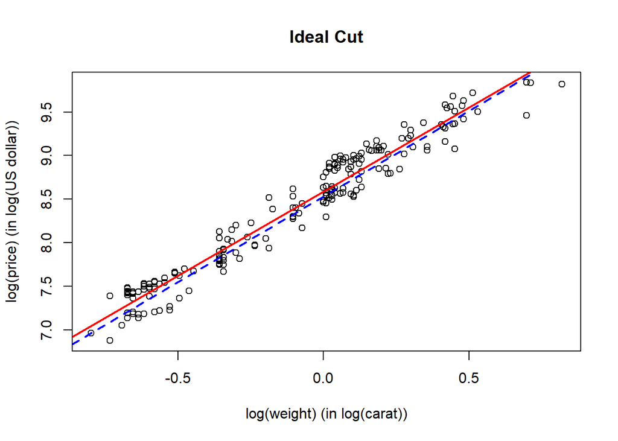

Three scatterplots for log(weight) against log(price) categorised by Cut. The red line is the fitted regression line for diamonds subset categorised by Cut, and the blue line is the fitted line from model M3 using the full dataset.

3. From the three plots for Good, Very Good and Ideal cut diamonds, we observe that: The regression lines for each cut group are similar in slope to each other and to the overall line from model M3. The intercepts differ slightly between the three cut groups. The relationship between log(price) and log(weight) is consistently linear across all levels of cut.

Merit of adding cut as a main effect: Adding cut as a main effect to model M3 is beneficial.Because the intercepts differ between cut categories, cut explains differences in the average price level at the same weight. Including cut as a main effect improves the model fit by accounting for these vertical shifts in price.

Merit of adding cut as main effect + interaction with log(weight): Adding an interaction term between cut and log(weight) is not necessary or beneficial.The slopes of the regression lines are nearly identical across the three cut groups, meaning the relationship between price and weight does not change across cut quality. The interaction term would not improve the model meaningfully.

|  | Res.Df | RSS | Df | Sum of Sq | F | Pr(>F) |
| --- | --- | --- | --- | --- | --- | --- |
| 1 | 605 | 16.75650 | NA | NA | NA | NA |
| 2 | 603 | 15.52601 | 2 | 1.230485 | 23.89482 | 1.031142e-10 |

$H_0$: All coefficients for cut are zero. $H_1$: At least one coefficient for cut is non-zero. The test statistic is the F-statistic, which under $H_0$ follows an F(2,603) distribution. Observed F-value = 23.895 and corresponding p-value = 1.031e-10 < 0.05. We reject $H_0$. Hence, Cut is highly significant and we include Cut variable to the model.

|  | Res.Df | RSS | Df | Sum of Sq | F | Pr(>F) |
| --- | --- | --- | --- | --- | --- | --- |
| 1 | 603 | 15.52601 | NA | NA | NA | NA |
| 2 | 601 | 15.44094 | 2 | 0.08507209 | 1.655609 | 0.1918454 |

$H_0$: All coefficients for the interaction cut:log(weight) are zero, given that main effects of cut and log(weight) are included. $H_1$: At least one interaction coefficient is non-zero , given that main effects of cut and log(weight) are included. The test statistic is the F-statistic, which under $H_0$ follows an F(2,601) distribution. Observed F-value = 1.6556 and corresponding p-value = 0.1918 > 0.05. We do not have enough evidence to reject $H_0$. Hence, there is no significant evidence that the interaction improves the model, so we do not include the interaction term between cut and log(weight).

```
Call:
lm(formula = log(price) ~ cut/log(weight), data = diamonds)

Residuals:
     Min       1Q   Median       3Q      Max
-0.50077 -0.11321 -0.01225  0.13273  0.33827

Coefficients:
                         Estimate Std. Error t value Pr(>|t|)
(Intercept)               8.47893    0.01132 749.253  < 2e-16 ***
cutIdeal                  0.10708    0.01648   6.497 1.72e-10 ***
cutVery Good              0.05284    0.01663   3.178  0.00156 **
cutGood:log(weight)       1.95629    0.03054  64.062  < 2e-16 ***
cutIdeal:log(weight)      1.93300    0.03089  62.577  < 2e-16 ***
cutVery Good:log(weight)  2.01222    0.03214  62.615  < 2e-16 ***
---
Signif. codes:  0 '***' 0.001 '**' 0.01 '*' 0.05 '.' 0.1 ' ' 1

Residual standard error: 0.1603 on 601 degrees of freedom
Multiple R-squared:  0.9523,    Adjusted R-squared:  0.9519
F-statistic:  2401 on 5 and 601 DF,  p-value: < 2.2e-16
```

For Ideal cut: log(price)=$(\beta_0+\gamma_0)+(\beta_1+\gamma_1) log(weight)$

$\beta_0$ = intercept for Good cut $\beta_1$= slope for Good cut $\delta_0$= intercept difference for Very Good and good cut $\gamma_0$= intercept difference for Ideal and good cut $\delta_1$= slope difference for Very Good and good cut $\gamma_1$= slope difference for Ideal and good cut

least squares estimate: $\beta_0$= 8.47893 $\gamma_0$= 0.10708 $\delta_0$= 0.05284 $\beta_1$= 1.95629 $\gamma_1$= 1.93300-1.95629=-0.02329 $\delta_1$= 2.01222-1.95629=0.05593

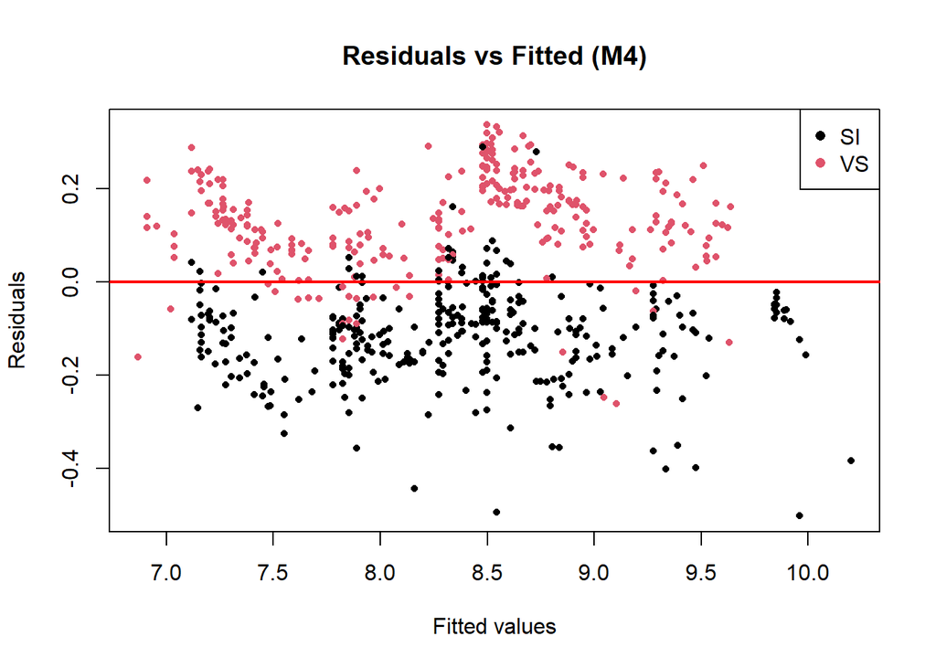

Residuals vs fitted values for model M4 (log(price) ~ log(weight) + cut), points colour-coded by diamond clarity.

The residuals show a clear pattern separated by colour (clarity). Different clarity levels cluster in distinct regions of residual values. Red(VS) points cluster above the red line and black(SI) points cluster below the red line. This indicates that clarity is strongly associated with the remaining variation in price not explained by log(weight) and cut. Therefore, adding clarity as an additional predictor is likely to significantly improve the model by explaining the structured residual variation.

|  | Res.Df | RSS | Df | Sum of Sq | F | Pr(>F) |
| --- | --- | --- | --- | --- | --- | --- |
| 1 | 603 | 15.526011 | NA | NA | NA | NA |
| 2 | 602 | 6.055849 | 1 | 9.470162 | 941.4102 | 3.503518e-125 |

1. Model under H0 (M4): log(price)∼log(weight)+cut

Model under H1 (M5): log(price)∼log(weight)+cut+clarity

2. $F = \frac{(RSS_{M4} - RSS_{M5}) / (df_{M4} - df_{M5})}{RSS_{M5} / df_{M5}}$
3. The variable clarity has 2 levels, so it adds 2−1=1 parameters. Thus numerator 1 degrees of freedom: $df_1=1$ Residual degrees of freedom for M5: Total observations n=607 M5 has parameters: intercept + log(weight) + cut(2) + clarity(1) = 5 parameters $df_2 = 607-5 = 602$ Therefore, under $H_0$ F∼F(1,602)
4. observed F = 941.41
5. p-value less than 0.001
6. reject $H_0$
7. There is very strong evidence that including clarity significantly improves the model for predicting log(price), after accounting for log(weight) and cut. Clarity is an important predictor of diamond prices and should be retained in the model.

c.Yes, we could have used a two-sided t-test. From the ANOVA table, we see that the difference in degrees of freedom between M4 and M5 is 1. This means the variable clarity adds only one single parameter to the model. When comparing two nested models that differ by exactly one parameter, the partial F-test is mathematically equivalent to a two-sided t-test for that single coefficient.